# Hepatitis C

```r
### EDAD
table_edad = table(data$Age)
p_table_edad = prop.table(table_edad)
p_table_edad
```

```
##
##          19          23          25          27          29          30
## 0.001626016 0.001626016 0.001626016 0.001626016 0.003252033 0.001626016
##          32          33          34          35          36          37
## 0.027642276 0.040650407 0.030894309 0.034146341 0.026016260 0.032520325
##          38          39          40          41          42          43
## 0.032520325 0.024390244 0.022764228 0.026016260 0.021138211 0.032520325
##          44          45          46          47          48          49
## 0.032520325 0.030894309 0.052032520 0.032520325 0.045528455 0.034146341
##          50          51          52          53          54          55
## 0.034146341 0.039024390 0.035772358 0.032520325 0.019512195 0.022764228
##          56          57          58          59          60          61
## 0.032520325 0.026016260 0.016260163 0.029268293 0.019512195 0.014634146
##          62          63          64          65          66          67
## 0.013008130 0.009756098 0.014634146 0.013008130 0.006504065 0.004878049
##          68          70          71          74          75          76
## 0.006504065 0.004878049 0.004878049 0.003252033 0.001626016 0.003252033
##          77
## 0.001626016
```

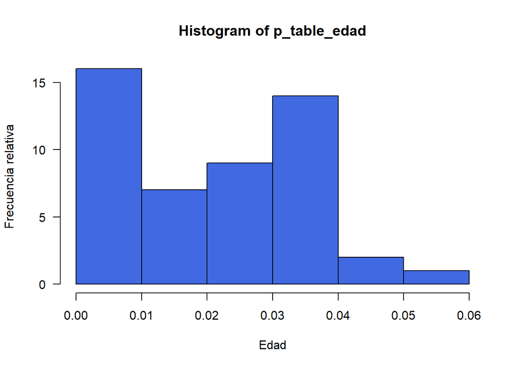

```r
hist(p_table_edad, xlab='Edad',
        ylab='Frecuencia relativa', las=1, col = c("royalblue"))
```

```r
### CATEGORIA
table_categoria = table(data$Category)
p_table_categoria = prop.table(table_categoria)
p_table_categoria
```

```
##
##          0=Blood Donor 0s=suspect Blood Donor            1=Hepatitis
##             0.86666667             0.01138211             0.03902439
##             2=Fibrosis            3=Cirrhosis
##             0.03414634             0.04878049
```

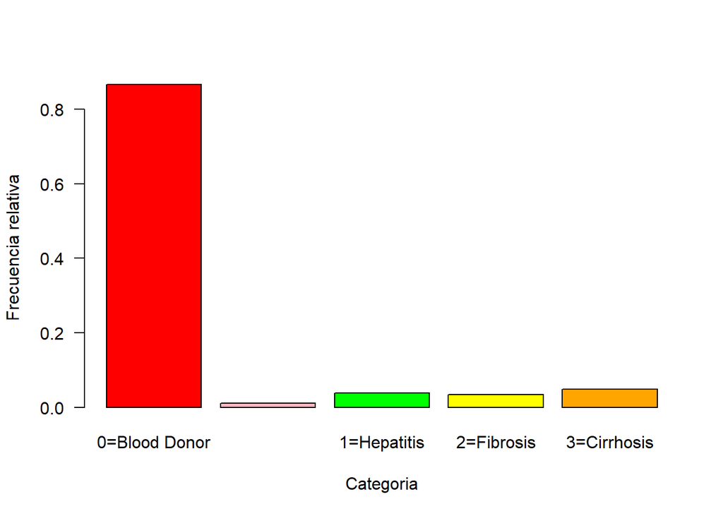

```r
barplot(p_table_categoria, xlab='Categoria',
        ylab='Frecuencia relativa', las=1, col = c("red", "lightpink", "green", "yellow", "orange"))
```

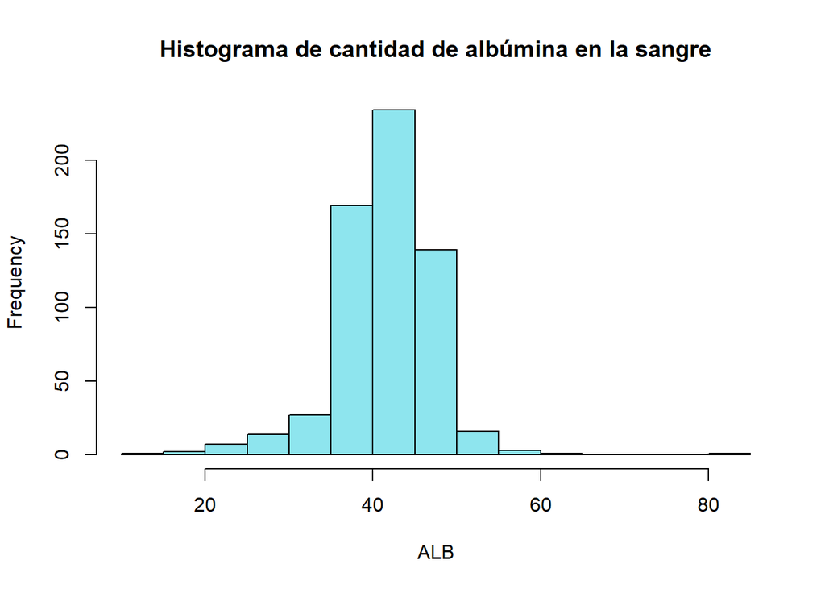

```r
### Histogramas de la frecuencias de las variables cuantitativas

hist(ALB,col="#8EE5EE", main = "Histograma de cantidad de albúmina en la sangre")
```

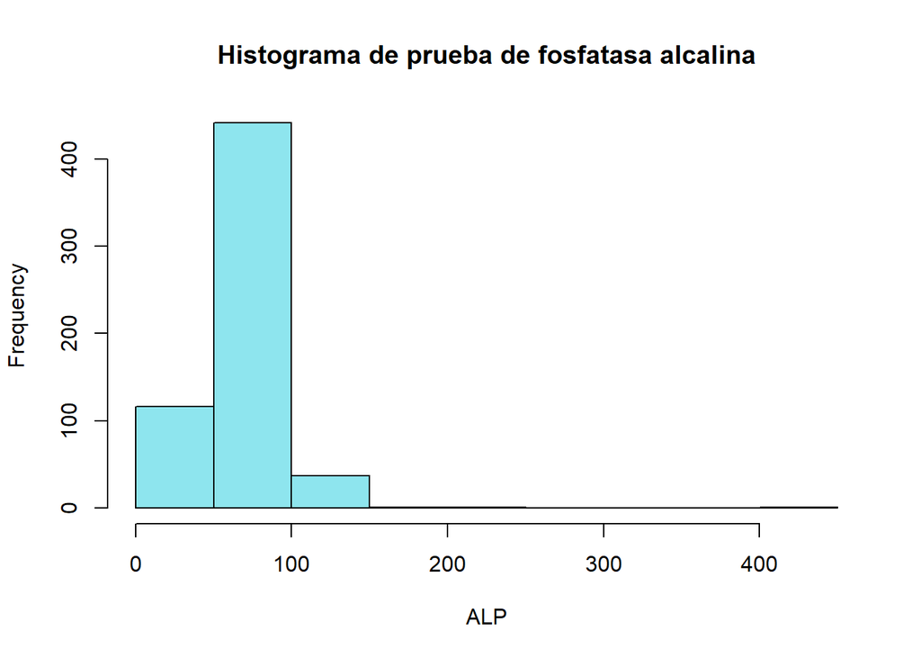

```r
hist(ALP,col="#8EE5EE", main = "Histograma de prueba de fosfatasa alcalina")
```

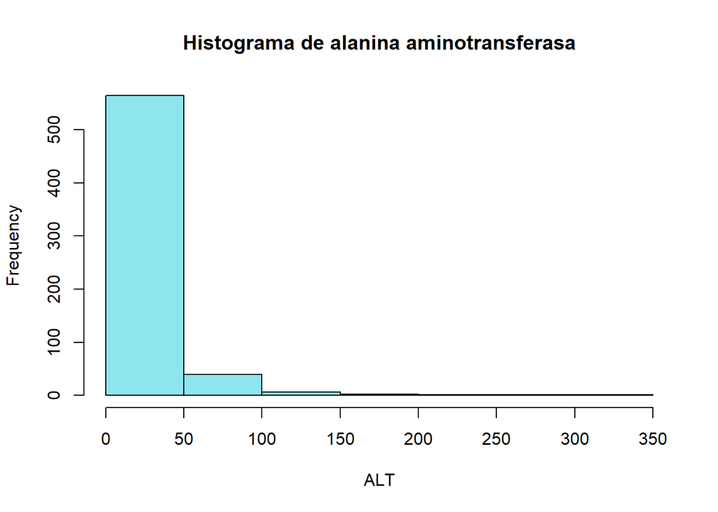

```r
hist(ALT,col="#8EE5EE", main = "Histograma de alanina aminotransferasa")
```

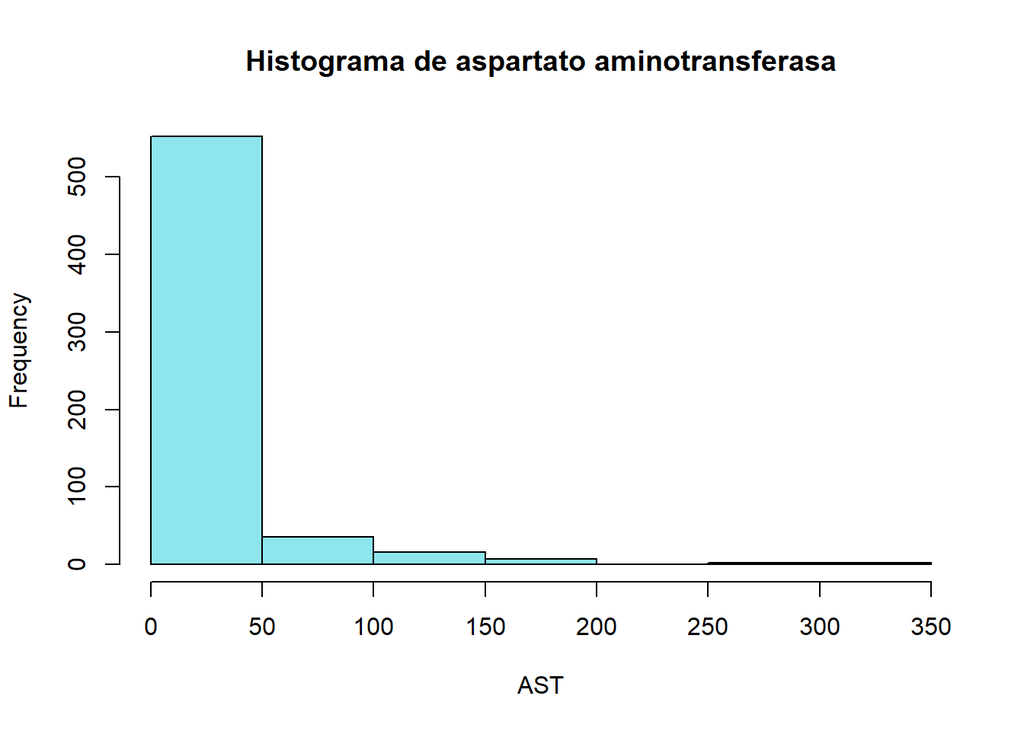

```r
hist(AST,col="#8EE5EE", main = "Histograma de aspartato aminotransferasa")
```

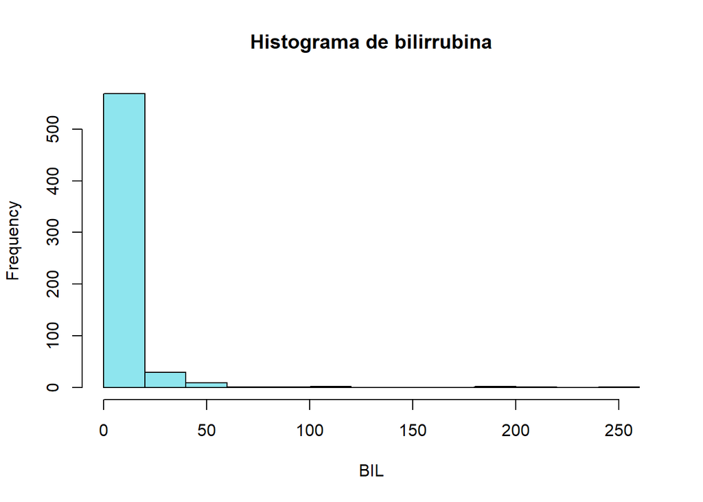

```r
hist(BIL,col="#8EE5EE", main = "Histograma de bilirrubina")
```

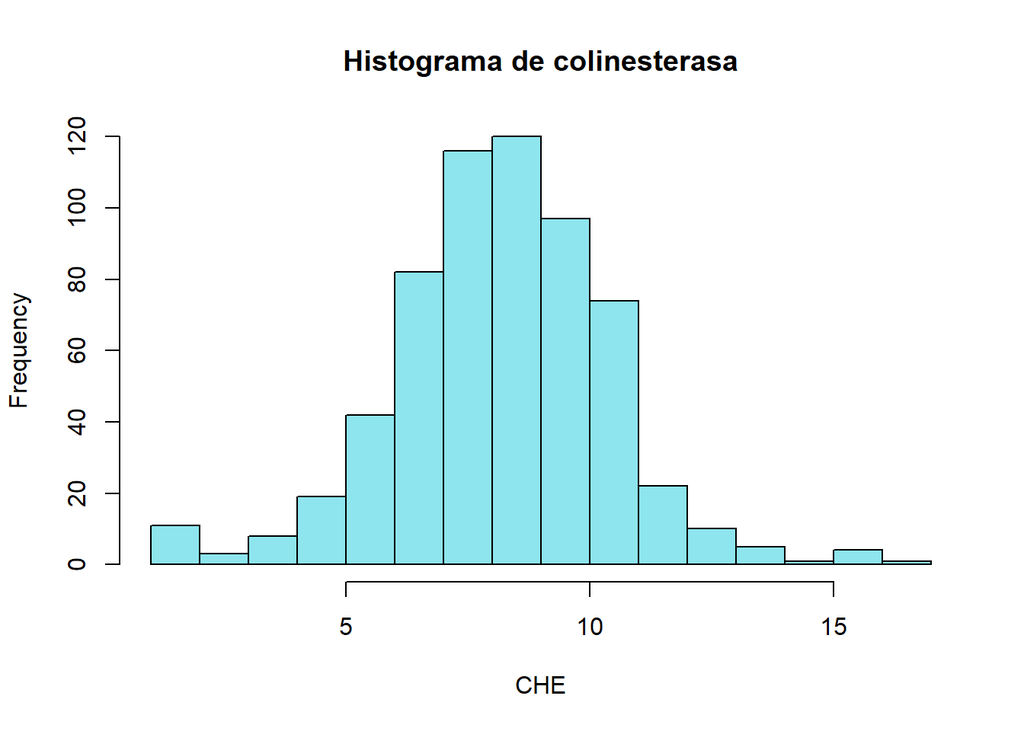

```r
hist(CHE,col="#8EE5EE", main = "Histograma de colinesterasa")
```

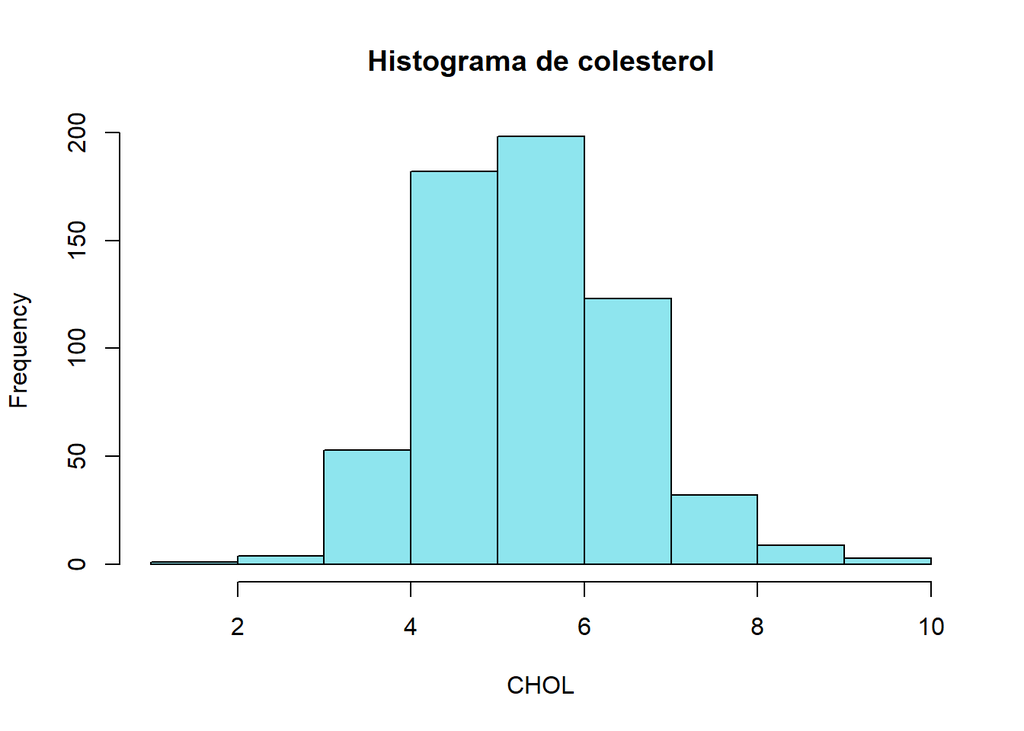

```r
hist(CHOL,col="#8EE5EE", main = "Histograma de colesterol")
```

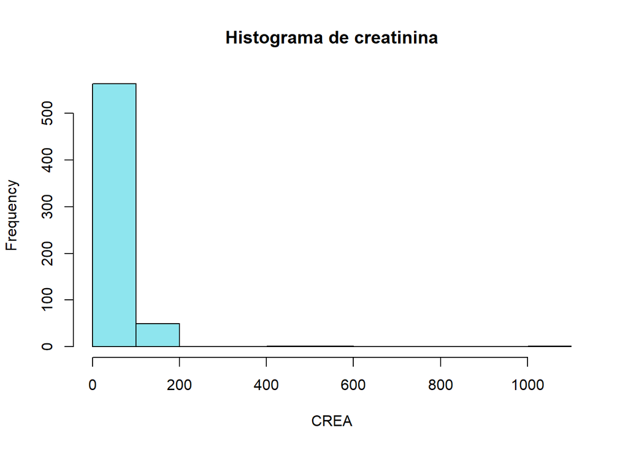

```r
hist(CREA,col="#8EE5EE", main = "Histograma de creatinina")
```

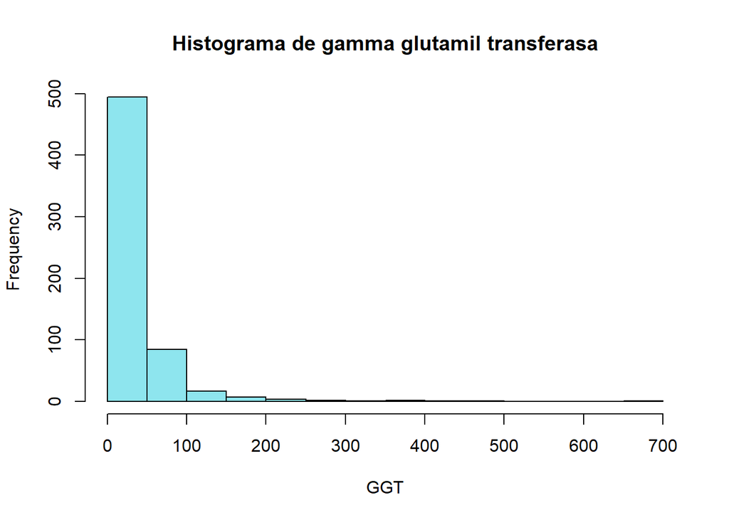

```r
hist(GGT,col="#8EE5EE", main = "Histograma de gamma glutamil transferasa")
```

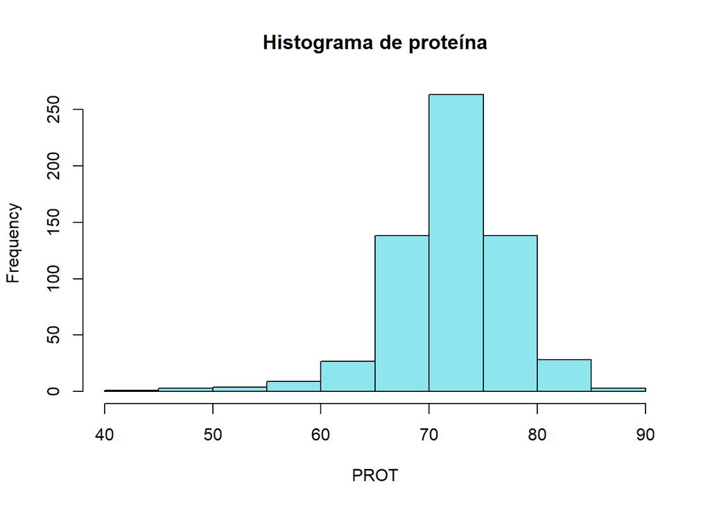

```r
hist(PROT,col="#8EE5EE", main = "Histograma de proteína")
```

- Matriz de correlación

```r
attach(data)
df_data = data.frame(Age, ALB, ALP, ALT, AST, BIL, CHE, CHOL, CREA, GGT, PROT)



m_corr = cor(na.omit(df_data))
m_corr
```

```
##              Age          ALB         ALP         ALT         AST         BIL
## Age   1.00000000 -0.191093637  0.17771977 -0.04057647  0.07273886  0.03965486
## ALB  -0.19109364  1.000000000 -0.14611991  0.03949714 -0.17760895 -0.16959750
## ALP   0.17771977 -0.146119911  1.00000000  0.22160301  0.06702428  0.05837241
## ALT  -0.04057647  0.039497139  0.22160301  1.00000000  0.19865775 -0.10679662
## AST   0.07273886 -0.177608947  0.06702428  0.19865775  1.00000000  0.30957974
## BIL   0.03965486 -0.169597498  0.05837241 -0.10679662  0.30957974  1.00000000
## CHE  -0.07586328  0.360919403  0.02948169  0.22434447 -0.19727042 -0.32071323
## CHOL  0.12474161  0.210419878  0.12590008  0.14999727 -0.20121300 -0.18156956
## CREA -0.02514225  0.001433247  0.15390895 -0.03610554 -0.01794810  0.01990962
## GGT   0.14337927 -0.147598318  0.46130000  0.21970686  0.47777362  0.21056656
## PROT -0.15975998  0.570725680 -0.06308514  0.01678633  0.01740394 -0.05257491
##              CHE         CHOL         CREA          GGT        PROT
## Age  -0.07586328  0.124741615 -0.025142253  0.143379268 -0.15975998
## ALB   0.36091940  0.210419878  0.001433247 -0.147598318  0.57072568
## ALP   0.02948169  0.125900079  0.153908950  0.461299996 -0.06308514
## ALT   0.22434447  0.149997271 -0.036105541  0.219706857  0.01678633
## AST  -0.19727042 -0.201213004 -0.017948098  0.477773617  0.01740394
## BIL  -0.32071323 -0.181569556  0.019909617  0.210566559 -0.05257491
## CHE   1.00000000  0.428018276 -0.012119999 -0.095716131  0.30628754
## CHOL  0.42801828  1.000000000 -0.051464078  0.008822692  0.24504950
## CREA -0.01212000 -0.051464078  1.000000000  0.125353469 -0.03011070
## GGT  -0.09571613  0.008822692  0.125353469  1.000000000 -0.03712701
## PROT  0.30628754  0.245049503 -0.030110695 -0.037127008  1.00000000
```

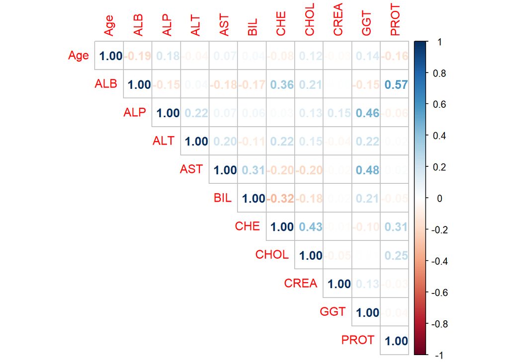

```r
corrplot(m_corr, method="number", type="upper")
```

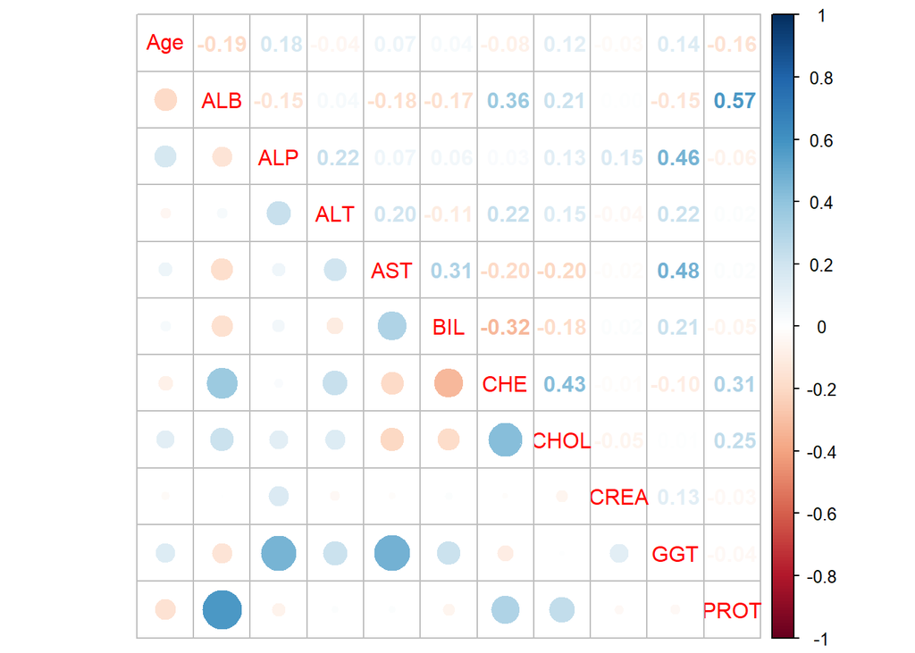

```r
corrplot.mixed(m_corr,lower = "circle",upper = "number")
```

- Matriz de covarianza

```r
m_cov=cov(df_data)
m_cov
```

```
##             Age ALB ALP ALT        AST        BIL        CHE CHOL        CREA
## Age  101.105146  NA  NA  NA   29.50184   6.427388  -1.665432   NA  -11.154950
## ALB          NA  NA  NA  NA         NA         NA         NA   NA          NA
## ALP          NA  NA  NA  NA         NA         NA         NA   NA          NA
## ALT          NA  NA  NA  NA         NA         NA         NA   NA          NA
## AST   29.501838  NA  NA  NA 1094.99379 203.262056 -15.220344   NA  -35.213310
## BIL    6.427388  NA  NA  NA  203.26206 387.032823 -14.457076   NA   30.563478
## CHE   -1.665432  NA  NA  NA  -15.22034 -14.457076   4.864924   NA   -1.224421
## CHOL         NA  NA  NA  NA         NA         NA         NA   NA          NA
## CREA -11.154950  NA  NA  NA  -35.21331  30.563478  -1.224421   NA 2475.676056
## GGT   84.140023  NA  NA  NA  888.58223 233.377730 -13.303611   NA  329.095812
## PROT         NA  NA  NA  NA         NA         NA         NA   NA          NA
##             GGT PROT
## Age    84.14002   NA
## ALB          NA   NA
## ALP          NA   NA
## ALT          NA   NA
## AST   888.58223   NA
## BIL   233.37773   NA
## CHE   -13.30361   NA
## CHOL         NA   NA
## CREA  329.09581   NA
## GGT  2987.83271   NA
## PROT         NA   NA
```

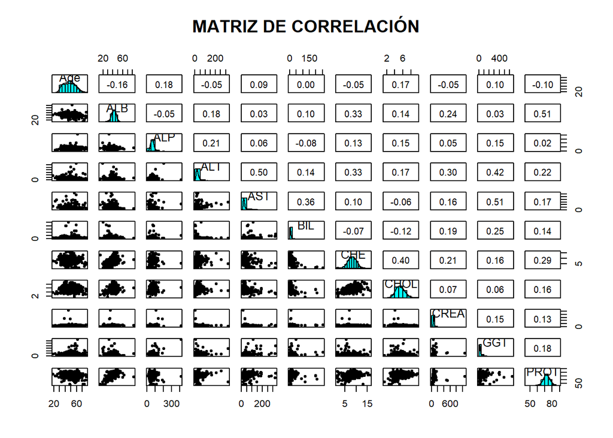

```r
pairs.panels(df_data, method = "spearman", ellipses = FALSE, smooth = FALSE, main = "MATRIZ DE CORRELACIÓN")
```

- Matriz de dispersión

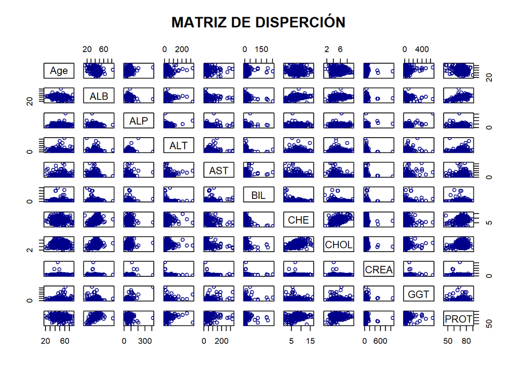

```r
pairs(df_data,col=("darkblue"), main= "MATRIZ DE DISPERCIÓN")
```

- Puntos de nube

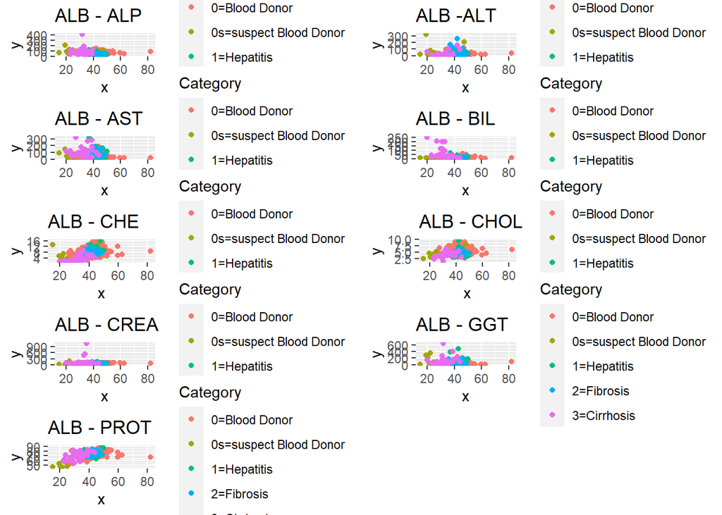

```r
geomPointGraph = function(data, x, y, Category, title){
  g = ggplot(data, aes(x, y)) +
    geom_point(aes(colour = Category)) +
    labs(title = title) +
    scale_fill_brewer(palette="Dark2")
  return(g)
}

f.ALP = geomPointGraph(data, data$ALB, data$ALP, data$Category, "ALB - ALP")
f.ALT = geomPointGraph(data, data$ALB, data$ALT, data$Category, "ALB -ALT")
f.AST = geomPointGraph(data, data$ALB, data$AST, data$Category, "ALB - AST")
f.BIL = geomPointGraph(data, data$ALB, data$BIL, data$Category, "ALB - BIL")
f.CHE = geomPointGraph(data, data$ALB, data$CHE, hcvdat$Category, "ALB - CHE")
f.CHOL = geomPointGraph(data, data$ALB, data$CHOL, data$Category, "ALB - CHOL")
f.CREA = geomPointGraph(data, data$ALB, data$CREA, data$Category, "ALB - CREA")
f.GGT = geomPointGraph(data, data$ALB, data$GGT, data$Category, "ALB - GGT")
f.PROT = geomPointGraph(data, data$ALB, data$PROT, data$Category, "ALB - PROT")


grid.arrange(f.ALP, f.ALT, f.AST, f.BIL, f.CHE, f.CHOL, f.CREA, f.GGT, f.PROT, ncol = 2)
```

- Preparacíon de los datos para realizar la predicción.

```r
df_h = data %>%
  mutate(Diagnosis = if_else(str_detect(Category, "Donor"), "Donor", "Hepatitis")) %>%
  mutate(Diagnosis = factor(Diagnosis, levels = c("Hepatitis", "Donor"))) %>%
  relocate(Diagnosis, .before = Category) %>%
  select(-Category)

df_h
```

```
##       X Diagnosis Age Sex  ALB   ALP   ALT   AST   BIL   CHE CHOL   CREA   GGT
## 1     1     Donor  32   m 38.5  52.5   7.7  22.1   7.5  6.93 3.23  106.0  12.1
## 2     2     Donor  32   m 38.5  70.3  18.0  24.7   3.9 11.17 4.80   74.0  15.6
## 3     3     Donor  32   m 46.9  74.7  36.2  52.6   6.1  8.84 5.20   86.0  33.2
## 4     4     Donor  32   m 43.2  52.0  30.6  22.6  18.9  7.33 4.74   80.0  33.8
## 5     5     Donor  32   m 39.2  74.1  32.6  24.8   9.6  9.15 4.32   76.0  29.9
## 6     6     Donor  32   m 41.6  43.3  18.5  19.7  12.3  9.92 6.05  111.0  91.0
## 7     7     Donor  32   m 46.3  41.3  17.5  17.8   8.5  7.01 4.79   70.0  16.9
## 8     8     Donor  32   m 42.2  41.9  35.8  31.1  16.1  5.82 4.60  109.0  21.5
## 9     9     Donor  32   m 50.9  65.5  23.2  21.2   6.9  8.69 4.10   83.0  13.7
## 10   10     Donor  32   m 42.4  86.3  20.3  20.0  35.2  5.46 4.45   81.0  15.9
## 11   11     Donor  32   m 44.3  52.3  21.7  22.4  17.2  4.15 3.57   78.0  24.1
## 12   12     Donor  33   m 46.4  68.2  10.3  20.0   5.7  7.36 4.30   79.0  18.7
## 13   13     Donor  33   m 36.3  78.6  23.6  22.0   7.0  8.56 5.38   78.0  19.4
## 14   14     Donor  33   m 39.0  51.7  15.9  24.0   6.8  6.46 3.38   65.0   7.0
```

[output cut: 1217 more lines]

- Split

División estratificada porque la clase objetivo está desequilibrada.

```r
set.seed(123)

data_split = initial_split(df_h, prop = 3/4, strata = Diagnosis)

df_train = training(data_split)
df_test = testing(data_split)
```

Procesamiento

- Imputar utilizando la mediana
- Convierta las variables nominales en ficticias (no es necesario para los modelos basados en árboles o la regresión logística, pero sin este paso, el paso de sobremuestreo no funcionará)
- Normalizar todos los predictores
- Equilibrar las clases de destino utilizando el algoritmo SMOTE.

```r
my_recipe = recipe(Diagnosis ~ ., data = df_train) %>%
  step_impute_median(all_numeric_predictors()) %>% # I use median
  step_dummy(all_nominal_predictors()) %>% # dummy goes before normalization
  step_normalize(all_predictors()) %>%
  step_smote(Diagnosis, over_ratio = 1, seed = 100) %>% # original target distribution 399 v 62
  check_missing(all_predictors())

my_recipe
```

```
## Recipe
##
## Inputs:
##
##       role #variables
##    outcome          1
##  predictor         13
##
## Operations:
##
## Median imputation for all_numeric_predictors()
## Dummy variables from all_nominal_predictors()
## Centering and scaling for all_predictors()
## SMOTE based on Diagnosis
## Check missing values for all_predictors()
```

- prep & bake

```r
train_data = my_recipe %>%
  prep(training = df_train) %>%
  bake(new_data = NULL) # df_train will be processed
```

- bake test

```r
test_data = my_recipe %>%
  prep( training = df_test) %>%
  bake(new_data = df_test)
```

- check oversampling results

```r
train_data %>% count(Diagnosis) # SMOTE was applied
```

```
## # A tibble: 2 × 2
##   Diagnosis     n
##   <fct>     <int>
## 1 Hepatitis   405
## 2 Donor       405
```

```r
test_data %>% count(Diagnosis) # not applied
```

```
## # A tibble: 2 × 2
##   Diagnosis     n
##   <fct>     <int>
## 1 Hepatitis    19
## 2 Donor       135
```

- Tabla

```r
formato = c("striped", "bordered", "hover", "responsive")

head(train_data) %>% kable() %>%
  kable_styling(bootstrap_options = formato,
                                    full_width = FALSE,
                                    position = "center",
                                    font_size = 16) %>%
  row_spec(0, bold = T, color = "blue")
```

| X | Age | ALB | ALP | ALT | AST | BIL | CHE | CHOL | CREA | GGT | PROT | Sex_m | Diagnosis |
| --- | --- | --- | --- | --- | --- | --- | --- | --- | --- | --- | --- | --- | --- |
| -1.746780 | -1.568303 | 0.8696136 | 0.2268714 | 0.3189555 | 0.5321286 | -0.2703939 | 0.2842254 | -0.1584700 | 0.0580831 | -0.1150301 | 1.3617317 | 0.7777896 | Donor |
| -1.741061 | -1.568303 | 0.2306182 | -0.6245329 | 0.0881259 | -0.3564658 | 0.4708214 | -0.4056597 | -0.5727346 | -0.0477591 | -0.1047319 | 0.6743633 | 0.7777896 | Donor |
| -1.735342 | -1.568303 | -0.4601876 | 0.2043673 | 0.1705650 | -0.2913022 | -0.0677178 | 0.4258574 | -0.9509763 | -0.1183205 | -0.1716702 | -0.6621864 | 0.7777896 | Donor |
| -1.729622 | -1.568303 | -0.0457041 | -0.9508421 | -0.4106311 | -0.4423632 | 0.0886323 | 0.7776532 | 0.6070190 | 0.4990922 | 0.8770300 | 0.3497726 | 0.7777896 | Donor |
| -1.723903 | -1.568303 | 0.7659927 | -1.0258557 | -0.4518507 | -0.4986409 | -0.1314160 | -0.5518605 | -0.5277059 | -0.2241627 | -0.3947979 | 0.4452405 | 0.7777896 | Donor |
| -1.718184 | -1.568303 | 0.0579168 | -1.0033516 | 0.3024677 | -0.1046974 | 0.3086806 | -1.0955448 | -0.6988152 | 0.4638115 | -0.3158450 | -0.9676835 | 0.7777896 | Donor |

- Sintonizar y ajustar la regresión logística penalizada
- Se realiza la regresión logística regularizada.
- Se eliminan las variables correlacionadas (umbral de correlación = 0,75)

```r
# recipe for LR
lr_recipe = recipe(Diagnosis ~ ., data = df_train) %>%
  step_impute_median(all_numeric_predictors()) %>% # I use median
  step_dummy(all_nominal_predictors()) %>% # dummy goes before normalization
  step_normalize(all_predictors()) %>%
  step_corr(threshold = 0.75) %>%
  step_smote(Diagnosis, over_ratio = 1, seed = 100) # original target distribution 399 v 62

# set model type/engine
lr_mod = logistic_reg(penalty = tune(), mixture = 1) %>%
  set_engine("glmnet")

# define the workflow
lr_workflow =
  workflow() %>%
  add_model(lr_mod) %>%
  add_recipe(lr_recipe)

# create a tune grid
lr_reg_grid = tibble(penalty = 10**seq(-4, 0, length.out = 30))

# Stratified, repeated 10-fold cross-validation
cv_folds = vfold_cv(df_train, strata = "Diagnosis", v = 10, repeats = 5)


cls_metrics = metric_set(roc_auc)

# train and tune the model
lr_res = tune_grid(lr_workflow,
              grid = lr_reg_grid,
              resamples = cv_folds,
              control = control_grid(save_pred = TRUE),
              metrics = cls_metrics)
```

- Resultados

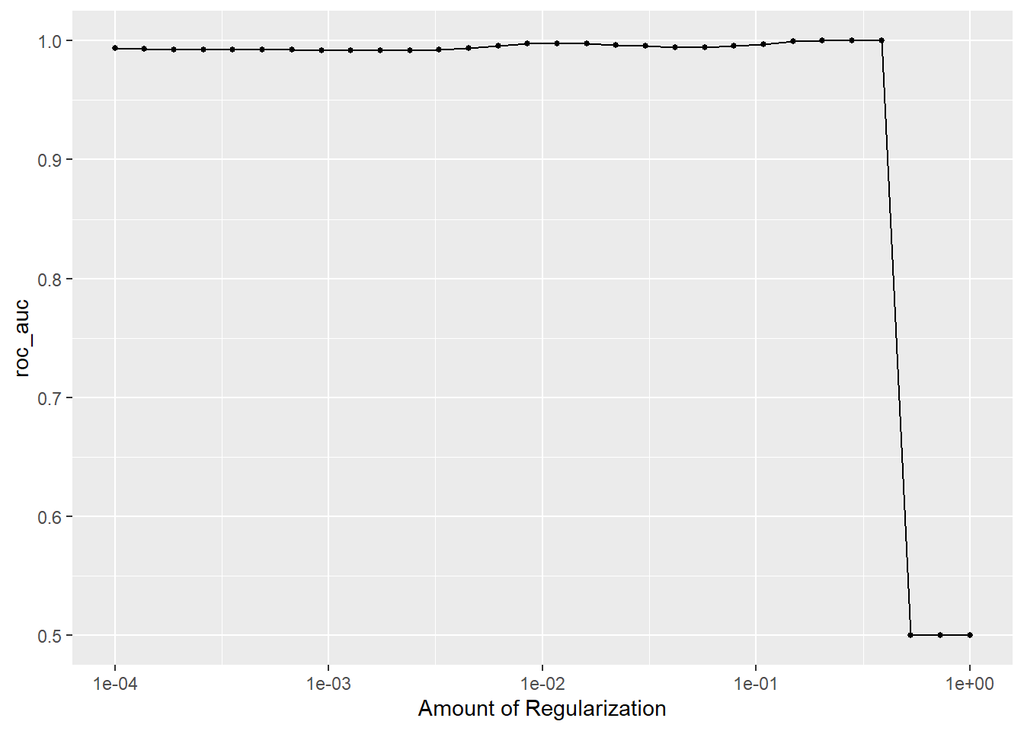

```r
autoplot(lr_res)
```

- Elección del mejor modelo

Aquí puede ver los 5 mejores modelos basados en el AUC medio y clasificados por puntaje de penalización:

```r
top_models =
  lr_res %>%
  show_best("roc_auc", n = 5) %>%
  arrange(penalty)

top_models %>% arrange(penalty)
```

```
## # A tibble: 5 × 7
##   penalty .metric .estimator  mean     n  std_err .config
##     <dbl> <chr>   <chr>      <dbl> <int>    <dbl> <chr>
## 1  0.0117 roc_auc binary     0.997    50 0.000857 Preprocessor1_Model16
## 2  0.149  roc_auc binary     0.999    50 0.000335 Preprocessor1_Model24
## 3  0.204  roc_auc binary     1        50 0        Preprocessor1_Model25
## 4  0.281  roc_auc binary     1        50 0        Preprocessor1_Model26
## 5  0.386  roc_auc binary     1        50 0        Preprocessor1_Model27
```

Elegiré un modelo con el AUC medio más alto

```r
lr_best = lr_res %>%
  select_best(metric = "roc_auc")

lr_best
```

```
## # A tibble: 1 × 2
##   penalty .config
##     <dbl> <chr>
## 1   0.204 Preprocessor1_Model25
```

- ROC-AUC del mejor modelo

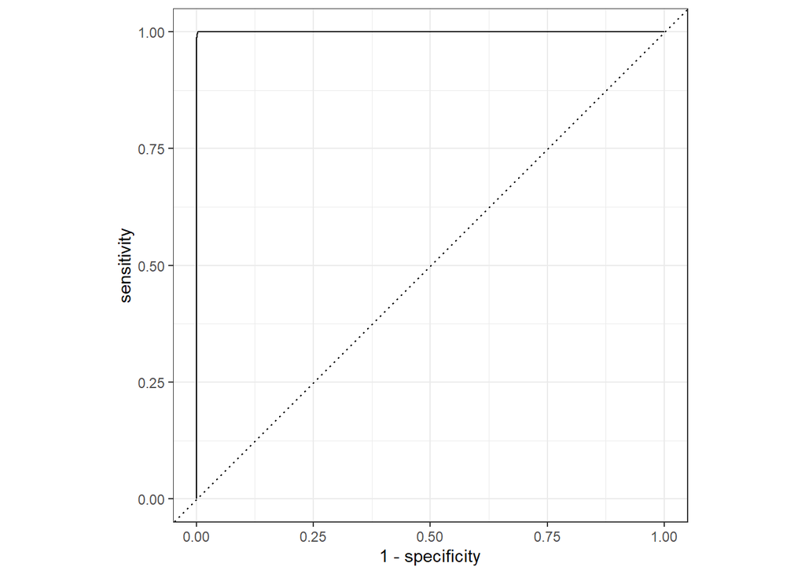

```r
lr_auc =
  lr_res %>%
  collect_predictions(parameters = lr_best) %>%
  roc_curve(Diagnosis, .pred_Hepatitis) %>%
  mutate(model = "Logistic Regression")

autoplot(lr_auc)
```